# Week 1 Homework

me

## Exercise One

For this exercise, you will need the Myopia Study dataset. Download the MYOPIA.dta Stata file, or you can also access the data through this CSV file.

One variable that is clearly important is the initial value of spherical equivalent refraction (SPHEQ).

Complete the following:

1. Write down the equation for the logistic regression model of SPHEQ on MYOPIA. Write down the equation for the logit transformation of this logistic regression model. What characteristic of the outcome variable, MYOPIA, leads us to consider the logistic regression model as opposed to the usual linear regression model to describe the relationship between MYOPIA and SPHEQ? Discuss your response in the homework forum.
2. Form a scatterplot of MYOPIA vs. SPHEQ.
3. Write down an expression for the likelihood and log likelihood for the logistic regression model in part (A) using the ungrouped, n=618, data. Obtain expressions for the two likelihood equations.
4. Using Stata, obtain the maximum likelihood estimates of the parameters of the logistic regression model in part (A). These estimates should be based on the ungrouped, n=618, data. Using these estimates, write down the equation for the fitted values, that is, the estimated logistic probabilities. Plot the equation for the fitted values on the axes used in the scatterplots in parts (B) and (C).

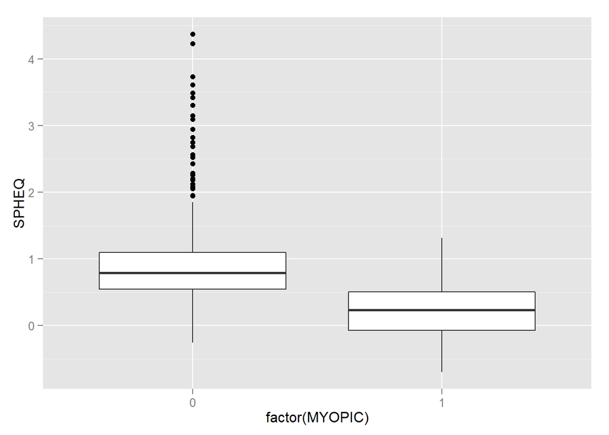

```r
library(ggplot2)
myopia <- read.csv("data/MYOPIA-fixed.csv")

plot1 <- ggplot(myopia, aes(factor(MYOPIC), SPHEQ)) +
  geom_boxplot()
plot1
```

```r
model1 <- glm(MYOPIC ~ SPHEQ, data = myopia, family = "binomial")
summary(model1)
```

```
##
## Call:
## glm(formula = MYOPIC ~ SPHEQ, family = "binomial", data = myopia)
##
## Deviance Residuals:
##     Min       1Q   Median       3Q      Max
## -1.6435  -0.4533  -0.2681  -0.1029   3.1602
##
## Coefficients:
##             Estimate Std. Error z value Pr(>|z|)
## (Intercept)  0.05397    0.20675   0.261    0.794
## SPHEQ       -3.83310    0.41837  -9.162   <2e-16 ***
## ---
## Signif. codes:  0 '***' 0.001 '**' 0.01 '*' 0.05 '.' 0.1 ' ' 1
##
## (Dispersion parameter for binomial family taken to be 1)
##
##     Null deviance: 480.08  on 617  degrees of freedom
## Residual deviance: 337.34  on 616  degrees of freedom
## AIC: 341.34
##
## Number of Fisher Scoring iterations: 6
```

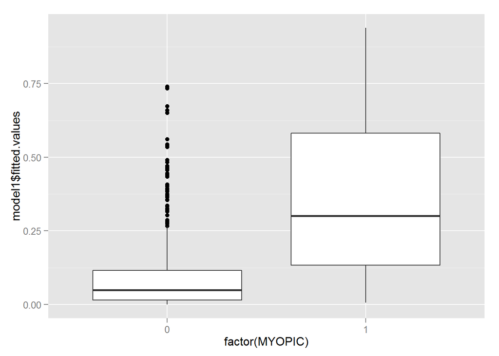

```r
plot2 <- ggplot(myopia, aes(factor(MYOPIC), model1$fitted.values)) +
  geom_boxplot()
plot2
```

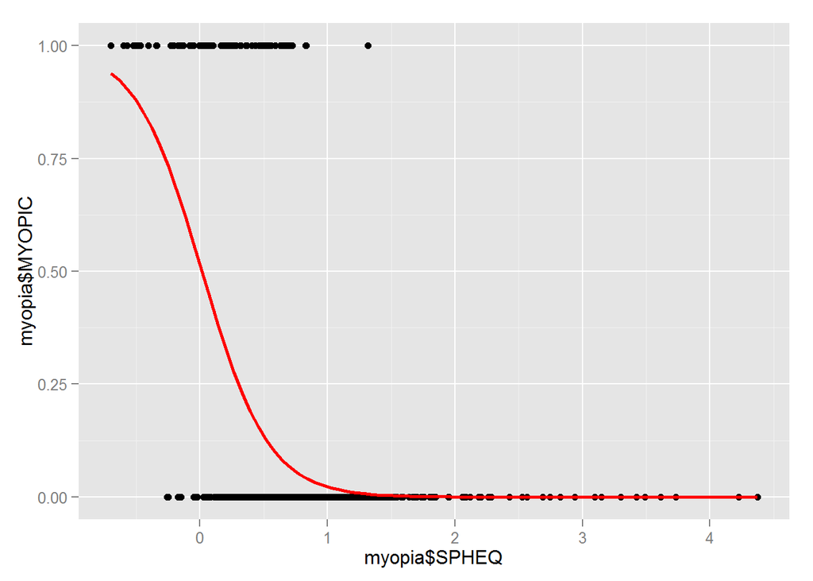

```r
qplot(y=myopia$MYOPIC, myopia$SPHEQ) +
  geom_smooth(method="glm", family="binomial", se=FALSE,
              color="red", lwd=1)
```

## Exercise Two

For this exercise, you will need the ICU dataset. Download the icu.dta Stata file, or you can also access the data through this CSV file.

The ICU dataset consists of a sample of 200 subjects who were part of a much larger study on survival of patients following admission to an adult intensive care unit (ICU). The major goal of this study was to develop a logistic regression model to predict the probability of survival to hospital discharge of these patients. A number of publications have appeared which have focused on various facets of this problem.

Complete the following:

1. Write down the equation for the logistic regression model of STA on AGE. Write down the equation for the logit transformation of this logistic regression model. What characteristic of the outcome variable, STA, leads us to consider the logistic regression model as opposed to the usual linear regression model to describe the relationship between STA and AGE?
2. Form a scatterplot of STA versus AGE.
3. Write down an expression for the likelihood and log likelihood for the logistic regression model in part (A) using the ungrouped, n=200, data. Obtain expressions for the two likelihood equations.
4. Using Stata, obtain the maximum likelihood estimates of the parameters of the logistic regression model in part (A). These estimates should be based on the ungrouped, n=200, data. Using these estimates, write down the equation for the fitted values, that is, the estimated logistic probabilities. Plot the equation for the fitted values on the axes used in the scatterplots in part (B).
5. Summarize (describe in words) the results presented in the plot obtained from parts (B) and (D).

### A

Logistic regression model:

$\pi(AGE) = {e^{\beta_{0} + \beta_{1}AGE} \over 1 + e^{\beta_{0} + \beta_{1}AGE}}$

Logit transformation:

$g(AGE) = \beta_{0} + \beta_{1}(AGE)$

> We consider the logistic regression model, rather than the usual linear regression model to describe the relationship between STA and AGE because the outcome variable, STA, is dichotomous, taking on the values 0 and 1.

### B

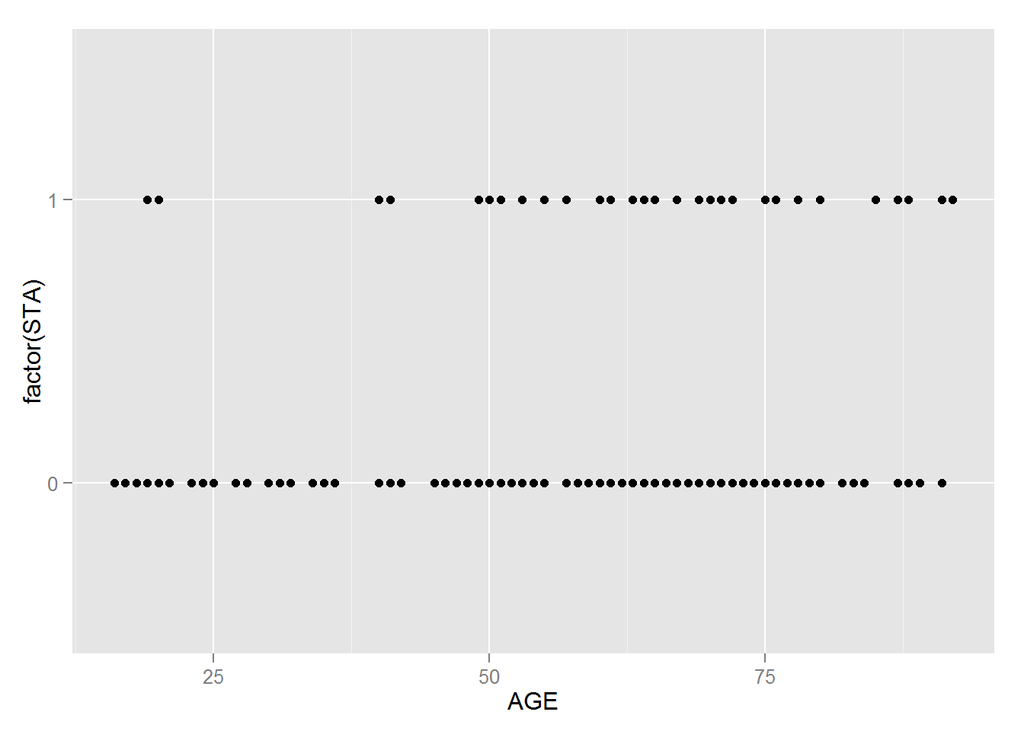

```r
data_icu <- read.csv("data/icu.csv")

plot1 <- ggplot(data_icu, aes(y = factor(STA), x = AGE)) +
  geom_point()
plot1
```

### C

likelihood function:

$\ell(\beta) = \prod_{i=1}^n \zeta(X_{i})$ where, $\zeta(X_{i}) = \pi(X_{i})^{y_{i}}[1 - \pi(X_{i})]^{1 - y_{i}}$

$X = AGE$ and $y_{i} = \begin{cases} 0 & \quad \text{if the patient lived}\\ 1 & \quad \text{if the patient died}\\ \end{cases}$

log likelihood function:

$L(\beta) = ln(\ell(\beta))$

### D

```r
icu_model <- glm(STA ~ AGE, data = data_icu, family = "binomial")
summary(icu_model)
```

```
##
## Call:
## glm(formula = STA ~ AGE, family = "binomial", data = data_icu)
##
## Deviance Residuals:
##     Min       1Q   Median       3Q      Max
## -0.9536  -0.7391  -0.6145  -0.3905   2.2854
##
## Coefficients:
##             Estimate Std. Error z value Pr(>|z|)
## (Intercept) -3.05851    0.69608  -4.394 1.11e-05 ***
## AGE          0.02754    0.01056   2.607  0.00913 **
## ---
## Signif. codes:  0 '***' 0.001 '**' 0.01 '*' 0.05 '.' 0.1 ' ' 1
##
## (Dispersion parameter for binomial family taken to be 1)
##
##     Null deviance: 200.16  on 199  degrees of freedom
## Residual deviance: 192.31  on 198  degrees of freedom
## AIC: 196.31
##
## Number of Fisher Scoring iterations: 4
```

log likelihood:

```r
logLik(icu_model)
```

```
## 'log Lik.' -96.15319 (df=2)
```

log likelihood ratio:

```r
icu_model$null.deviance - icu_model$deviance
```

```
## [1] 7.854589
```

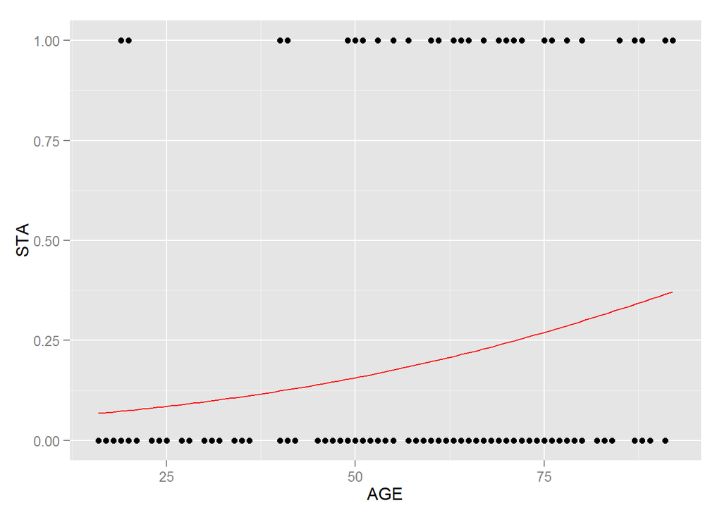

```r
qplot(y = STA, x = AGE, data = data_icu) +
  geom_smooth(method="glm", family="binomial", se=FALSE,
              color="red")
```

> The plot of STA vs. AGE (indicated in the scatterplot in 1(b)) demonstrates the dichotomous nature of the STA variable, which takes on the value zero if a patient is discharged alive or the value one if the patient died prior to discharge. The plot suggests that older people are more likely to die in the ICU, although overall, people are more likely to live than to die.

> The plot of the estimated logistic probabilities vs. AGE (in Exercise 1(d)) indicates that the probability of dying does increase with increasing age. The rate of increase in the probabilities seems to increase with increasing age.